# SI 618 Homework 3

## Getting Data from a SQLite Database (10 points)

In the data preparation step, you created a SQLite database and populated it with vehicle data. Now retrieve this data using the R package DBI and RSQLite, and store it in a data frame named vehicles. You should omit any rows with missing data.

Here are the first 10 rows of the resulting data frame, and the summary.

```
## [1] TRUE
```

```
##    year       make               model          VClass cylinders displ
## 1  1985 Alfa Romeo  Spider Veloce 2000     Two Seaters         4   2.0
## 2  1985    Ferrari          Testarossa     Two Seaters        12   4.9
## 3  1985      Dodge             Charger Subcompact Cars         4   2.2
## 4  1985      Dodge B150/B250 Wagon 2WD            Vans         8   5.2
## 5  1993     Subaru    Legacy AWD Turbo    Compact Cars         4   2.2
## 6  1993     Subaru              Loyale    Compact Cars         4   1.8
## 7  1993     Subaru              Loyale    Compact Cars         4   1.8
## 8  1993     Toyota             Corolla    Compact Cars         4   1.6
## 9  1993     Toyota             Corolla    Compact Cars         4   1.6
## 10 1993     Toyota             Corolla    Compact Cars         4   1.8
##              trany city08 highway08 comb08
## 1     Manual 5-spd     19        25     21
## 2     Manual 5-spd      9        14     11
## 3     Manual 5-spd     23        33     27
## 4  Automatic 3-spd     10        12     11
## 5     Manual 5-spd     17        23     19
## 6  Automatic 3-spd     21        24     22
## 7     Manual 5-spd     22        29     25
## 8  Automatic 3-spd     23        26     24
## 9     Manual 5-spd     23        31     26
## 10 Automatic 4-spd     23        30     25
```

```
##       year          make              model              VClass
##  Min.   :1984   Length:33145       Length:33145       Length:33145
##  1st Qu.:1989   Class :character   Class :character   Class :character
##  Median :1998   Mode  :character   Mode  :character   Mode  :character
##  Mean   :1998
##  3rd Qu.:2006
##  Max.   :2014
##    cylinders          displ          trany               city08
##  Min.   : 2.000   Min.   :1.000   Length:33145       Min.   : 6.00
##  1st Qu.: 4.000   1st Qu.:2.200   Class :character   1st Qu.:15.00
##  Median : 6.000   Median :3.000   Mode  :character   Median :17.00
##  Mean   : 5.741   Mean   :3.331                      Mean   :17.33
##  3rd Qu.: 6.000   3rd Qu.:4.300                      3rd Qu.:20.00
##  Max.   :16.000   Max.   :8.400                      Max.   :53.00
##    highway08         comb08
##  Min.   : 9.00   Min.   : 7.00
##  1st Qu.:19.00   1st Qu.:16.00
##  Median :23.00   Median :19.00
##  Mean   :23.36   Mean   :19.54
##  3rd Qu.:27.00   3rd Qu.:22.00
##  Max.   :61.00   Max.   :53.00
```

## Converting to Factors (5 points)

To make downstream analysis easier, convert the data in columns make, VClass, cylinders, and trany into factors. Here's the summary of the data frame after the conversion.

```
##       year             make          model
##  Min.   :1984   Chevrolet: 3469   Length:33145
##  1st Qu.:1989   Ford     : 2798   Class :character
##  Median :1998   Dodge    : 2392   Mode  :character
##  Mean   :1998   GMC      : 2216
##  3rd Qu.:2006   Toyota   : 1712
##  Max.   :2014   BMW      : 1276
##                 (Other)  :19282
##                          VClass        cylinders         displ
##  Compact Cars               : 4730   4      :12573   Min.   :1.000
##  Subcompact Cars            : 4436   6      :11627   1st Qu.:2.200
##  Midsize Cars               : 3599   8      : 7391   Median :3.000
##  Standard Pickup Trucks     : 2352   5      :  745   Mean   :3.331
##  Sport Utility Vehicle - 4WD: 2087   12     :  448   3rd Qu.:4.300
##  Sport Utility Vehicle - 2WD: 1614   3      :  175   Max.   :8.400
##  (Other)                    :14327   (Other):  186
##              trany           city08        highway08         comb08
##  Automatic 4-spd:10994   Min.   : 6.00   Min.   : 9.00   Min.   : 7.00
##  Manual 5-spd   : 8173   1st Qu.:15.00   1st Qu.:19.00   1st Qu.:16.00
##  Automatic 3-spd: 3151   Median :17.00   Median :23.00   Median :19.00
##  Automatic 5-spd: 2105   Mean   :17.33   Mean   :23.36   Mean   :19.54
##  Manual 6-spd   : 1877   3rd Qu.:20.00   3rd Qu.:27.00   3rd Qu.:22.00
##  (Other)        : 6840   Max.   :53.00   Max.   :61.00   Max.   :53.00
##  NA's           :    5
```

## Aggregating by multiple variables (15 points)

First, find all combinations of car company (the 'make' column) and vehicle class (the 'VClass' column) that have at least 20 years of mileage data for that class, and list them here.

```
##              make                     VClass year_count
## 1           Acura               Compact Cars         25
## 10          Acura            Subcompact Cars         21
## 23           Audi               Compact Cars         21
## 26           Audi               Midsize Cars         27
## 30           Audi       Small Station Wagons         22
## 33           Audi            Subcompact Cars         22
## 47            BMW               Compact Cars         30
## 48            BMW                 Large Cars         20
## 49            BMW               Midsize Cars         22
## 56            BMW            Subcompact Cars         30
## 62          Buick                 Large Cars         28
## 64          Buick               Midsize Cars         30
## 79       Cadillac                 Large Cars         29
## 80       Cadillac               Midsize Cars         30
```

[output cut: 74 more lines]

## Filtering (10 points)

Now filter the vehicles dataset to include only those records having the combination of car company and vehicle class listed above. Hint: One way to do this is using the merge() function, which is like a SQL JOIN.

As part of this filtering step, remove any vehicle classes from the VClass factor that are not used in the filtered subset.

Now output the summary of the filtered dataset:

```
##             make                   VClass       year_count
##  Chevrolet    : 931   Compact Cars    :3804   Min.   :20.00
##  BMW          : 922   Subcompact Cars :3197   1st Qu.:24.00
##  Mercedes-Benz: 817   Midsize Cars    :2950   Median :28.00
##  Ford         : 791   Large Cars      : 986   Mean   :26.76
##  Pontiac      : 700   Two Seaters     : 901   3rd Qu.:30.00
##  Toyota       : 658   Minicompact Cars: 432   Max.   :31.00
##  (Other)      :8074   (Other)         : 623
##       year         model             cylinders        displ
##  Min.   :1984   Length:12893       4      :5762   Min.   :1.000
##  1st Qu.:1990   Class :character   6      :4354   1st Qu.:2.000
##  Median :1999   Mode  :character   8      :1953   Median :2.500
##  Mean   :1998                      5      : 378   Mean   :2.946
##  3rd Qu.:2007                      12     : 237   3rd Qu.:3.600
##  Max.   :2014                      3      : 101   Max.   :7.000
##                                    (Other): 108
##              trany          city08        highway08         comb08
##  Automatic 4-spd:3791   Min.   : 6.00   Min.   : 9.00   Min.   : 7.0
##  Manual 5-spd   :3333   1st Qu.:16.00   1st Qu.:23.00   1st Qu.:19.0
##  Automatic 3-spd:1200   Median :18.00   Median :26.00   Median :21.0
##  Manual 6-spd   :1188   Mean   :18.87   Mean   :26.07   Mean   :21.5
##  Automatic 5-spd: 759   3rd Qu.:21.00   3rd Qu.:29.00   3rd Qu.:24.0
##  (Other)        :2621   Max.   :53.00   Max.   :61.00   Max.   :53.0
##  NA's           :   1
```

## Plotting Fuel Economy of Vehicles of Different Makes (30 points)

For each vehicle class in this filtered subset of vehicles (the VClass column), plot the following two charts with ggplot().

A. Plot mean combined MPG (average of data in the comb08 columns) for each vehicle maker, for every year. Use two layers: a layer showing the individual data points, and a smoothed line (without the grey confidence region) fit to the points. Use color to visually distinguish each maker in the plot, and be sure to add a plot title naming the vehicle class.

Hint: to set ggplot default text size to something a bit more readable, use: theme_set(theme_grey(base_size = 18))

B. Compute and plot the mean combined MPG in all years for each vehicle maker. Note how the vehicle makers are ranked by ascending mean combined MPG in the second plot.

Hint: To get the vertical x-axis labels I added this to my ggplot expression: + theme(axis.text.x = element_text(angle = 90, hjust = 1))

Note: do not simply cut and paste code multiple times to create all the vehicle class plots. You should be able to generate all these plots with a single block of R statements.

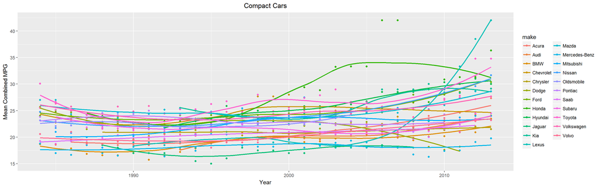

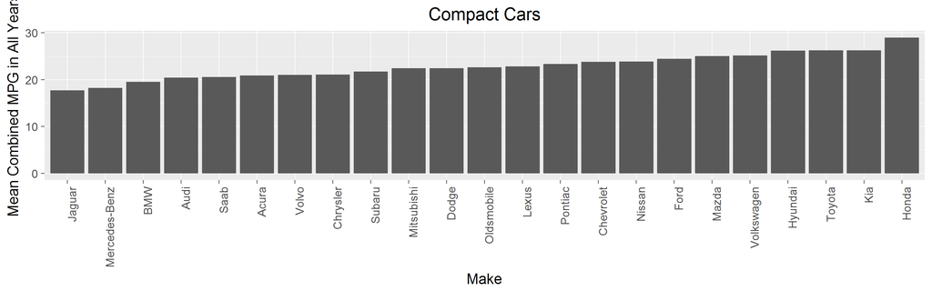

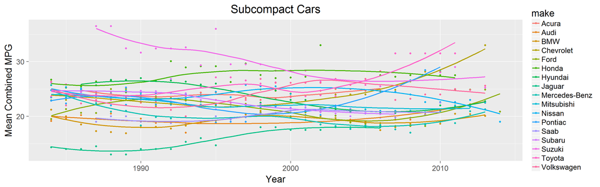

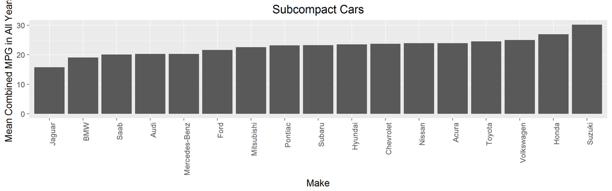

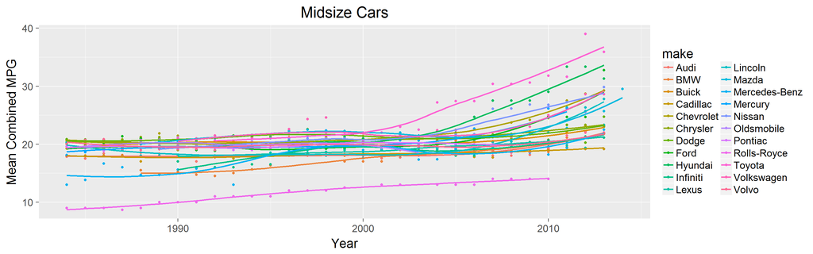

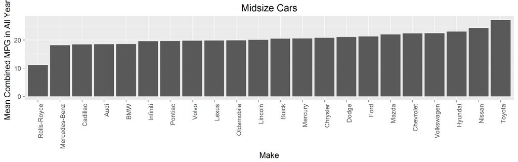

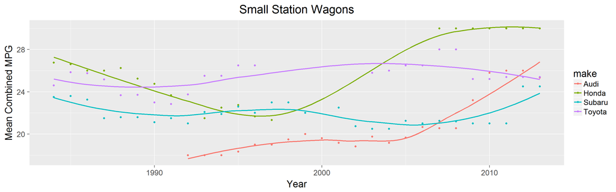

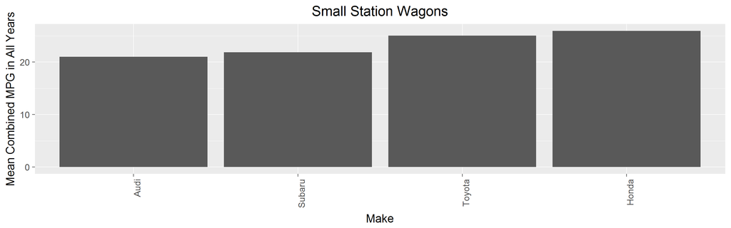

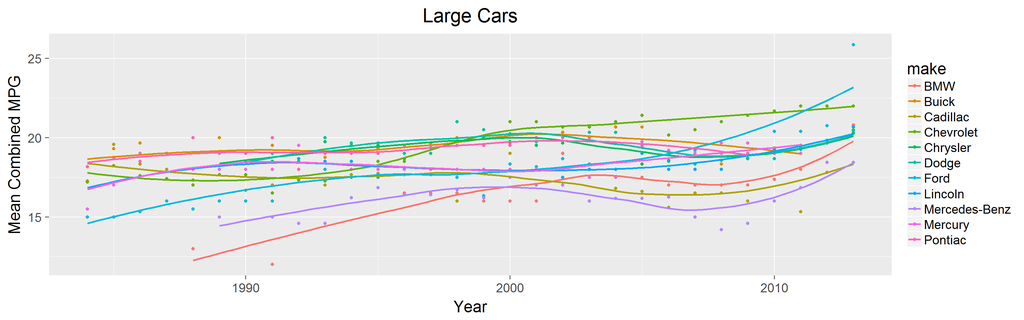

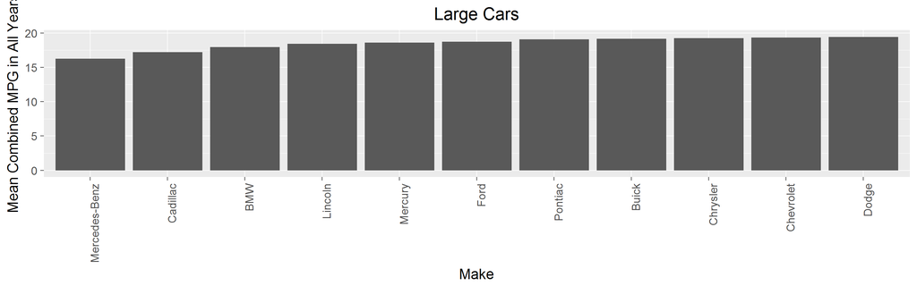

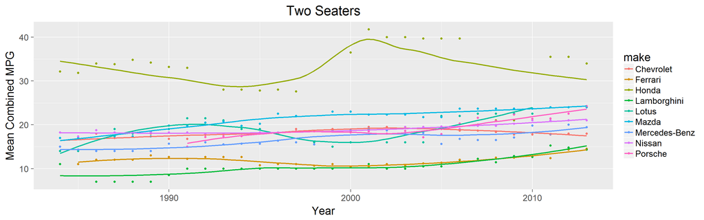

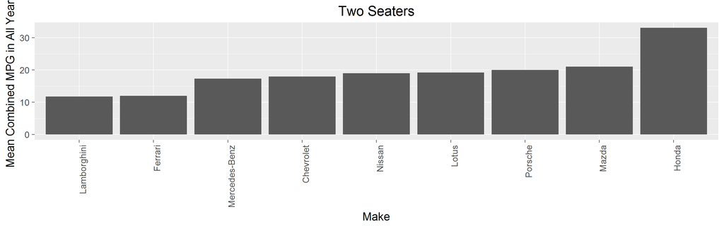

[4 more figures not shown]